# Практична робота № 18

## Метрологічні основи контролю за рівнем розвитку фізичної якості **сили**

**Мета заняття:** навчитися методиці оцінки силових якостей спортсменів.

| **Дисципліна** | Спортивна метрологія |
| --- | --- |
| **Практичне заняття** | № 18 |

## 1. Визначення сили як фізичної якості людини

### 1.1 Поняття силових якостей

**Силові якості** — це здатність людини долати зовнішній опір або протидіяти йому за рахунок м'язових зусиль. Від рівня їх розвитку залежать досягнення практично у всіх видах спорту.

Методи контролю за силовими якостями мають давню історію. Перші механічні пристрої для вимірювання сили були створені ще у **XVIII столітті**.

### 1.2 Групи показників при контролі силових якостей

При контролі за силовими якостями враховують **три групи показників**:

| № | Група | Показники |
| --- | --- | --- |
| 1 | **Основні** | а) миттєві значення сили у будь-який момент руху, зокрема **максимальна сила**; б) **середня сила** |
| 2 | **Інтегральні** | **Імпульс сили** (площа під кривою F(t)) |
| 3 | **Диференціальні** | **Градієнт сили** (швидкість зміни миттєвих значень сили) |

### 1.3 Фізичні основи

Згідно із **законами механіки**, кінцевий ефект дії сили визначається **імпульсом сили**:

$$I = \int_{t_1}^{t_2} F(t)\, dt$$

Якщо сила постійна:

$$I = F \cdot t$$

**Середня сила** — умовний показник, рівний відношенню імпульсу сили до часу її дії:

$$\bar{F} = \frac{I}{t} = \frac{\int F(t)\, dt}{t}$$

**Градієнт сили** (диференціальний показник) — швидкість наростання сили:

$$G_F = \frac{dF}{dt} \quad \text{або} \quad G_F = \frac{F_{\max}}{t_{F_{\max}}}$$

## 2. Види сили

### 2.1 Класифікація видів сили

| Вид сили | Характеристика | Застосування |
| --- | --- | --- |
| **Максимальна сила** | Найвищий рівень напруги, що може розвинути м'яз. Характеризує абсолютну силу | Важка атлетика, боротьба |
| **Вибухова сила** | Здатність досягти максимуму сили за мінімальний час | Стрибки, метання, спринт |
| **Силова витривалість** | Здатність тривалий час підтримувати значні силові зусилля | Веслування, плавання |
| **Відносна сила** | Максимальна сила відносно маси тіла спортсмена | Єдиноборства (вагові категорії) |
| **Динамічна сила** | Сила, що проявляється під час руху | Більшість видів спорту |
| **Статична сила** | Сила, що проявляється без руху (ізометрично) | Важка атлетика, боротьба |

### 2.2 Зони силових якостей при контролі без апаратури

При метанні предметів різної маси виділяють три зони:

- **Зона I** (малі обтяження) → характеризує **швидкісні** якості
- **Зона II** (середні обтяження) → характеризує **швидкісно-силові** якості
- **Зона III** (значні обтяження) → характеризує **силові** якості

### 2.3 Показники надійності силових тестів

| Тип тесту | Коефіцієнт надійності $r_{tt}$ |
| --- | --- |
| Механічні динамометри | 0,60 – 0,80 |
| Градієнти сили (будь-який спосіб) | 0,70 – 0,80 |
| Тензометричні пристрої (максимальна сила) | 0,85 – 0,95 |

## 3. Контроль за рівнем розвитку сили

### 3.1 Способи реєстрації силових якостей

**Спосіб 1 — без вимірювальної апаратури:**

- Оцінка за найбільшою вагою, яку здатний підняти або утримати спортсмен
- **Прямий спосіб:** максимальна сила = найбільша вага у жимі штанги лежачи тощо
- **Непрямий спосіб:** стрибки в довжину/висоту, метання набивних м'ячів, підтягування

**Спосіб 2 — з вимірювальними пристроями:**

- **Динамометри** (механічні пружинного типу: ДПУ-1000, ДПУ-2000, ДПУ-5000 Н, похибка ≤ 2 %)
- **Динамографи** (безперервний запис F(t))
- **Тензометричні пристрої** (найточніші; дозволяють вимірювати будь-які силові показники)

### 3.2 Типи силовимірювальних установок

| Тип | Принцип | Особливість |
| --- | --- | --- |
| **Деформаційний** | Вимірює деформацію тіла, до якого прикладена сила | Статичні або квазістатичні зусилля |
| **Інерційний динамограф** | Вимірює прискорення рухомого тіла | Вимірювання сили в русі |

### 3.3 Метрологічні вимоги до вимірювання силових якостей

1. Визначати та стандартизувати **положення тіла (суглоба)** при повторних спробах
2. Враховувати **довжину сегментів тіла** при вимірюванні моментів сили
3. Враховувати **напрям вектора сили**
4. Дотримуватись загальних метрологічних вимог до контролю за фізичною підготовленістю

# Розрахунково-графічна робота № 2

## «Метрологічний аналіз показників силової підготовленості спортсменів»

### Завдання роботи:

1. Розрахувати **основні статистичні показники** вибірки результатів вимірювання сили
2. Побудувати **нормувальну шкалу** для оцінки рівня силової підготовленості
3. Розрахувати **імпульс сили**, **середню силу** та **градієнт сили** за динамограмою
4. Розрахувати **відносну силу** спортсменів
5. Визначити **надійність тесту** (коефіцієнт кореляції між двома спробами)
6. Побудувати **графіки** та зробити висновки

```python
import numpy as np
import pandas as pd
import matplotlib.pyplot as plt
import matplotlib.patches as mpatches
from scipy import stats
from scipy.integrate import trapezoid
import warnings
warnings.filterwarnings('ignore')

# Налаштування відображення графіків
plt.rcParams['figure.figsize'] = (12, 6)
plt.rcParams['font.size'] = 12
plt.rcParams['axes.grid'] = True
plt.rcParams['grid.alpha'] = 0.3
plt.rcParams['font.family'] = 'DejaVu Sans'

print("Бібліотеки імпортовано успішно.")
```

```
Бібліотеки імпортовано успішно.
```

## Завдання 1. Первинні дані та статистичний аналіз

### Умова:

Проведено **динамометрію кисті** (вимірювання максимальної сили стискання кисті) у групі спортсменів (n = 20). Вимірювання проведено двічі (спроба 1 і спроба 2) для оцінки надійності тесту.

Одиниця вимірювання: **кілограми-сила (кгс)** або **Ньютони (Н)**, 1 кгс = 9,81 Н.

```python
# ============================================================
# ВИХІДНІ ДАНІ
# ============================================================

# Прізвища спортсменів
names = [
    'Андрієнко', 'Бойко', 'Василенко', 'Гнатенко', 'Демченко',
    'Єременко', 'Захаренко', 'Іваненко', 'Коваленко', 'Литвиненко',
    'Марченко', 'Назаренко', 'Олексієнко', 'Петренко', 'Романенко',
    'Савченко', 'Тимченко', 'Удовенко', 'Філіпенко', 'Харченко'
]

# Маса тіла (кг)
body_weight = np.array([
    75, 82, 68, 90, 78,
    85, 72, 88, 76, 81,
    70, 93, 65, 87, 79,
    84, 73, 91, 77, 83
])

# Динамометрія кисті – спроба 1 (кгс)
grip_1 = np.array([
    48, 55, 42, 61, 51,
    58, 46, 63, 49, 54,
    44, 67, 40, 59, 52,
    57, 47, 65, 50, 56
])

# Динамометрія кисті – спроба 2 (кгс)
grip_2 = np.array([
    47, 56, 43, 60, 52,
    59, 45, 62, 50, 55,
    45, 66, 41, 60, 53,
    58, 48, 64, 51, 55
])

# Краща спроба (max із двох)
grip_best = np.maximum(grip_1, grip_2)

# Відносна сила (кгс / кг тіла)
relative_strength = grip_best / body_weight

# Формування таблиці даних
df = pd.DataFrame({
    'Спортсмен':       names,
    'Маса тіла (кг)':  body_weight,
    'Спроба 1 (кгс)':  grip_1,
    'Спроба 2 (кгс)':  grip_2,
    'Краща спроба (кгс)': grip_best,
    'Відносна сила':   relative_strength.round(3)
})

print("=" * 75)
print("ТАБЛИЦЯ 1. Результати динамометрії кисті (n = 20 спортсменів)")
print("=" * 75)
print(df.to_string(index=False))
print("=" * 75)
```

```
===========================================================================
ТАБЛИЦЯ 1. Результати динамометрії кисті (n = 20 спортсменів)
===========================================================================
 Спортсмен  Маса тіла (кг)  Спроба 1 (кгс)  Спроба 2 (кгс)  Краща спроба (кгс)  Відносна сила
 Андрієнко              75              48              47                  48          0.640
     Бойко              82              55              56                  56          0.683
 Василенко              68              42              43                  43          0.632
  Гнатенко              90              61              60                  61          0.678
  Демченко              78              51              52                  52          0.667
  Єременко              85              58              59                  59          0.694
 Захаренко              72              46              45                  46          0.639
  Іваненко              88              63              62                  63          0.716
 Коваленко              76              49              50                  50          0.658
Литвиненко              81              54              55                  55          0.679
  Марченко              70              44              45                  45          0.643
 Назаренко              93              67              66                  67          0.720
Олексієнко              65              40              41                  41          0.631
  Петренко              87              59              60                  60          0.690
 Романенко              79              52              53                  53          0.671
  Савченко              84              57              58                  58          0.690
  Тимченко              73              47              48                  48          0.658
  Удовенко              91              65              64                  65          0.714
 Філіпенко              77              50              51                  51          0.662
  Харченко              83              56              55                  56          0.675
===========================================================================
```

### 1.1 Розрахунок основних статистичних показників

Для характеристики вибірки розраховують:

| Показник | Формула |
| --- | --- |
| Середнє арифметичне | $\bar{x} = \dfrac{\sum x_i}{n}$ |
| Середнє квадратичне відхилення | $\sigma = \sqrt{\dfrac{\sum(x_i - \bar{x})^2}{n-1}}$ |
| Коефіцієнт варіації | $V = \dfrac{\sigma}{\bar{x}} \cdot 100\%$ |
| Похибка середнього | $m = \dfrac{\sigma}{\sqrt{n}}$ |
| Мінімум, максимум, розмах | $W = x_{\max} - x_{\min}$ |

```python
def calc_stats(data, label):
    """Розраховує та виводить описову статистику."""
    n    = len(data)
    mean = np.mean(data)
    std  = np.std(data, ddof=1)
    cv   = (std / mean) * 100
    sem  = std / np.sqrt(n)
    mn   = np.min(data)
    mx   = np.max(data)
    w    = mx - mn
    med  = np.median(data)
    return {
        'Показник': label,
        'n':        n,
        'M (середнє)':  round(mean, 2),
        'σ (відхилення)': round(std, 2),
        'V% (варіація)':  round(cv, 1),
        'm (похибка)':    round(sem, 2),
        'Min':            round(mn, 2),
        'Max':            round(mx, 2),
        'W (розмах)':     round(w, 2),
        'Медіана':        round(med, 2)
    }

stats_grip1  = calc_stats(grip_1, 'Динамометрія кисті – спроба 1 (кгс)')
stats_grip2  = calc_stats(grip_2, 'Динамометрія кисті – спроба 2 (кгс)')
stats_best   = calc_stats(grip_best, 'Динамометрія кисті – краща спроба (кгс)')
stats_rel    = calc_stats(relative_strength, 'Відносна сила (кгс/кг)')

stats_df = pd.DataFrame([stats_grip1, stats_grip2, stats_best, stats_rel])

print("\n" + "=" * 90)
print("ТАБЛИЦЯ 2. Описова статистика показників силової підготовленості")
print("=" * 90)
print(stats_df.set_index('Показник').T.to_string())
print("=" * 90)

M   = np.mean(grip_best)
sig = np.std(grip_best, ddof=1)
n   = len(grip_best)

print(f"\nОсновні параметри кращої спроби:")
print(f"  M  = {M:.2f} кгс")
print(f"  σ  = {sig:.2f} кгс")
print(f"  V% = {(sig/M*100):.1f}%  → ", end="")
if sig/M*100 < 10:
    print("однорідна група (V < 10%)")
elif sig/M*100 < 20:
    print("помірно однорідна група (10% ≤ V < 20%)")
else:
    print("неоднорідна група (V ≥ 20%)")
```

```
==========================================================================================
ТАБЛИЦЯ 2. Описова статистика показників силової підготовленості
==========================================================================================
Показник        Динамометрія кисті – спроба 1 (кгс)  Динамометрія кисті – спроба 2 (кгс)  Динамометрія кисті – краща спроба (кгс)  Відносна сила (кгс/кг)
n                                             20.00                                20.00                                    20.00                   20.00
M (середнє)                                   53.20                                53.50                                    53.85                    0.67
σ (відхилення)                                 7.63                                 7.21                                     7.41                    0.03
V% (варіація)                                 14.30                                13.50                                    13.80                    4.10
m (похибка)                                    1.71                                 1.61                                     1.66                    0.01
Min                                           40.00                                41.00                                    41.00                    0.63
Max                                           67.00                                66.00                                    67.00                    0.72
W (розмах)                                    27.00                                25.00                                    26.00                    0.09
Медіана                                       53.00                                54.00                                    54.00                    0.67
==========================================================================================

Основні параметри кращої спроби:
  M  = 53.85 кгс
  σ  = 7.41 кгс
  V% = 13.8%  → помірно однорідна група (10% ≤ V < 20%)
```

## Завдання 2. Побудова нормувальної шкали оцінки

У спортивній метрології для оцінки рівня розвитку фізичних якостей використовують **п'ятирівневу нормувальну шкалу** на основі сигмальних відхилень:

| Рівень | Межі | Оцінка |
| --- | --- | --- |
| Низький | $x < M - 1{,}5\sigma$ | 1 (незадовільно) |
| Нижче середнього | $M - 1{,}5\sigma \leq x < M - 0{,}5\sigma$ | 2 (задовільно) |
| Середній | $M - 0{,}5\sigma \leq x < M + 0{,}5\sigma$ | 3 (добре) |
| Вище середнього | $M + 0{,}5\sigma \leq x < M + 1{,}5\sigma$ | 4 (відмінно) |
| Високий | $x \geq M + 1{,}5\sigma$ | 5 (відмінно+) |

```python
# Межі нормувальної шкали
boundaries = {
    'Низький':              (0,           M - 1.5*sig),
    'Нижче середнього':     (M - 1.5*sig, M - 0.5*sig),
    'Середній':             (M - 0.5*sig, M + 0.5*sig),
    'Вище середнього':      (M + 0.5*sig, M + 1.5*sig),
    'Високий':              (M + 1.5*sig, 999)
}

print("=" * 70)
print("ТАБЛИЦЯ 3. Нормувальна шкала – динамометрія кисті (кгс)")
print(f"  M = {M:.2f} кгс,  σ = {sig:.2f} кгс")
print("=" * 70)
print(f"{'Рівень':<22} {'Нижня межа':>12} {'Верхня межа':>12} {'Оцінка':>8}")
print("-" * 70)

scores = [1, 2, 3, 4, 5]
labels_list = list(boundaries.keys())
for i, (level, (lo, hi)) in enumerate(boundaries.items()):
    lo_str = f"{lo:.1f}" if lo > 0 else "< -"
    hi_str = f"{hi:.1f}" if hi < 999 else "і вище"
    print(f"{level:<22} {lo_str:>12} {hi_str:>12} {scores[i]:>8}")

print("=" * 70)

# Присвоєння оцінок кожному спортсмену
def assign_score(x, M, sig):
    if   x < M - 1.5*sig:  return 1
    elif x < M - 0.5*sig:  return 2
    elif x < M + 0.5*sig:  return 3
    elif x < M + 1.5*sig:  return 4
    else:                   return 5

df['Оцінка'] = [assign_score(v, M, sig) for v in grip_best]
df['Рівень підготовленості'] = df['Оцінка'].map({
    1: 'Низький', 2: 'Нижче середнього',
    3: 'Середній', 4: 'Вище середнього', 5: 'Високий'
})

print("\nТАБЛИЦЯ 4. Індивідуальна оцінка силової підготовленості")
print("=" * 70)
print(df[['Спортсмен', 'Краща спроба (кгс)', 'Оцінка', 'Рівень підготовленості']].to_string(index=False))

print("\n" + "=" * 50)
print("Розподіл спортсменів за рівнями:")
print("=" * 50)
dist = df['Рівень підготовленості'].value_counts()
order = ['Низький', 'Нижче середнього', 'Середній', 'Вище середнього', 'Високий']
for level in order:
    count = dist.get(level, 0)
    pct   = count / len(df) * 100
    print(f"  {level:<22}: {count:2d} осіб  ({pct:.0f}%)")
```

```
======================================================================
ТАБЛИЦЯ 3. Нормувальна шкала – динамометрія кисті (кгс)
  M = 53.85 кгс,  σ = 7.41 кгс
======================================================================
Рівень                   Нижня межа  Верхня межа   Оцінка
----------------------------------------------------------------------
Низький                         < -         42.7        1
Нижче середнього               42.7         50.1        2
Середній                       50.1         57.6        3
Вище середнього                57.6         65.0        4
Високий                        65.0       і вище        5
======================================================================

ТАБЛИЦЯ 4. Індивідуальна оцінка силової підготовленості
======================================================================
 Спортсмен  Краща спроба (кгс)  Оцінка Рівень підготовленості
 Андрієнко                  48       2       Нижче середнього
     Бойко                  56       3               Середній
 Василенко                  43       2       Нижче середнього
  Гнатенко                  61       4        Вище середнього
  Демченко                  52       3               Середній
  Єременко                  59       4        Вище середнього
 Захаренко                  46       2       Нижче середнього
  Іваненко                  63       4        Вище середнього
 Коваленко                  50       2       Нижче середнього
Литвиненко                  55       3               Середній
  Марченко                  45       2       Нижче середнього
 Назаренко                  67       5                Високий
Олексієнко                  41       1                Низький
  Петренко                  60       4        Вище середнього
 Романенко                  53       3               Середній
  Савченко                  58       4        Вище середнього
  Тимченко                  48       2       Нижче середнього
  Удовенко                  65       5                Високий
 Філіпенко                  51       3               Середній
  Харченко                  56       3               Середній

==================================================
Розподіл спортсменів за рівнями:
==================================================
  Низький               :  1 осіб  (5%)
  Нижче середнього      :  6 осіб  (30%)
  Середній              :  6 осіб  (30%)
  Вище середнього       :  5 осіб  (25%)
  Високий               :  2 осіб  (10%)
```

## Завдання 3. Аналіз динамограми — імпульс, середня сила, градієнт

### Умова:

Записано **динамограму** (залежність сили F від часу t) при відштовхуванні спортсмена від опори. Визначити:

- Максимальну силу $F_{\max}$
- Час досягнення максимуму $t_{F_{\max}}$
- Імпульс сили $I = \int F(t)\,dt$
- Середню силу $\bar{F} = I / T$
- Градієнт сили $G_F = F_{\max} / t_{F_{\max}}$

```python
# ============================================================
# Модель динамограми відштовхування
# ============================================================

# Часова вісь (с)
T_total = 0.35           # загальний час фази відштовхування, с
dt      = 0.001
t       = np.arange(0, T_total + dt, dt)

# Маса тіла спортсмена
m_body  = 80             # кг
F_body  = m_body * 9.81  # сила тяжіння, Н

# Синтез реалістичної кривої F(t):
# фаза наростання (0 … t_peak), фаза зниження (t_peak … T_total)
t_peak = 0.12            # час до максимуму, с
F_max  = 2200            # максимальна сила, Н

F = np.where(
    t <= t_peak,
    F_body + (F_max - F_body) * np.sin(np.pi / 2 * t / t_peak)**1.6,
    F_body + (F_max - F_body) * np.exp(-4.5 * (t - t_peak) / (T_total - t_peak))
)
# Невеликий шум для реалістичності
np.random.seed(42)
F += np.random.normal(0, 15, size=len(t))
F = np.clip(F, 0, None)

# ============================================================
# РОЗРАХУНКИ
# ============================================================

F_max_val    = np.max(F)
t_Fmax       = t[np.argmax(F)]
F_mean       = np.mean(F)
impulse      = trapezoid(F, t)           # імпульс (Н·с)
F_avg_from_I = impulse / T_total         # середня сила через імпульс
gradient_F   = F_max_val / t_Fmax        # градієнт сили

# ============================================================
# ВИВЕДЕННЯ
# ============================================================
print("=" * 55)
print("РЕЗУЛЬТАТИ АНАЛІЗУ ДИНАМОГРАМИ")
print("=" * 55)
print(f"  Максимальна сила  F_max          = {F_max_val:.1f} Н")
print(f"  Час до максимуму  t(F_max)       = {t_Fmax:.3f} с")
print(f"  Загальний час     T              = {T_total:.3f} с")
print(f"  Імпульс сили      I = ∫F(t)dt   = {impulse:.2f} Н·с")
print(f"  Середня сила      F_avg = I/T    = {F_avg_from_I:.1f} Н")
print(f"  Градієнт сили     G_F = F/t(F)  = {gradient_F:.1f} Н/с")
print("=" * 55)
print(f"\n  Відносна сила     F_max / G_тіла = {F_max_val/F_body:.2f}")
print(f"  (F_тіла = {F_body:.1f} Н  при масі {m_body} кг)")
```

```
=======================================================
РЕЗУЛЬТАТИ АНАЛІЗУ ДИНАМОГРАМИ
=======================================================
  Максимальна сила  F_max          = 2227.5 Н
  Час до максимуму  t(F_max)       = 0.113 с
  Загальний час     T              = 0.350 с
  Імпульс сили      I = ∫F(t)dt   = 438.53 Н·с
  Середня сила      F_avg = I/T    = 1253.0 Н
  Градієнт сили     G_F = F/t(F)  = 19712.0 Н/с
=======================================================

  Відносна сила     F_max / G_тіла = 2.84
  (F_тіла = 784.8 Н  при масі 80 кг)
```

## Завдання 4. Визначення надійності тесту

Надійність тесту оцінюється **коефіцієнтом кореляції** між результатами першої та другої спроб:

$$r_{tt} = \frac{\sum(x_{1i} - \bar{x}_1)(x_{2i} - \bar{x}_2)}{\sqrt{\sum(x_{1i} - \bar{x}_1)^2 \cdot \sum(x_{2i} - \bar{x}_2)^2}}$$

**Критерії оцінки надійності:**

| $r_{tt}$ | Рівень надійності |
| --- | --- |
| ≥ 0,90 | Відмінна |
| 0,80 – 0,89 | Хороша |
| 0,70 – 0,79 | Задовільна |
| < 0,70 | Незадовільна |

```python
# Коефіцієнт кореляції Пірсона
r_tt, p_value = stats.pearsonr(grip_1, grip_2)

# Значущість через t-критерій
n_s   = len(grip_1)
t_obs = r_tt * np.sqrt(n_s - 2) / np.sqrt(1 - r_tt**2)
t_cr  = stats.t.ppf(0.975, df=n_s - 2)   # критичне значення при α=0.05

# Стандартна похибка вимірювання
SEM_meas = np.std(grip_best, ddof=1) * np.sqrt(1 - r_tt)

print("=" * 60)
print("ОЦІНКА НАДІЙНОСТІ ТЕСТУ ДИНАМОМЕТРІЇ КИСТІ")
print("=" * 60)
print(f"  Кількість спортсменів  n    = {n_s}")
print(f"  Коефіцієнт кореляції   r_tt = {r_tt:.4f}")
print(f"  p-значення             p    = {p_value:.6f}")
print(f"  t-спостережуване       t    = {t_obs:.3f}")
print(f"  t-критичне (α=0.05)    t_cr = {t_cr:.3f}")
print(f"  Похибка вимірювання    SEM  = {SEM_meas:.2f} кгс")
print("-" * 60)

if   r_tt >= 0.90: rel_level = "ВІДМІННА"
elif r_tt >= 0.80: rel_level = "ХОРОША"
elif r_tt >= 0.70: rel_level = "ЗАДОВІЛЬНА"
else:              rel_level = "НЕЗАДОВІЛЬНА"

print(f"  Рівень надійності:  {rel_level}  (r_tt = {r_tt:.4f})")

if t_obs > t_cr:
    print(f"  Зв'язок СТАТИСТИЧНО ЗНАЧУЩИЙ (t={t_obs:.2f} > t_cr={t_cr:.2f})")
else:
    print(f"  Зв'язок НЕ значущий (t={t_obs:.2f} < t_cr={t_cr:.2f})")

print("=" * 60)
```

```
============================================================
ОЦІНКА НАДІЙНОСТІ ТЕСТУ ДИНАМОМЕТРІЇ КИСТІ
============================================================
  Кількість спортсменів  n    = 20
  Коефіцієнт кореляції   r_tt = 0.9928
  p-значення             p    = 0.000000
  t-спостережуване       t    = 35.260
  t-критичне (α=0.05)    t_cr = 2.101
  Похибка вимірювання    SEM  = 0.63 кгс
------------------------------------------------------------
  Рівень надійності:  ВІДМІННА  (r_tt = 0.9928)
  Зв'язок СТАТИСТИЧНО ЗНАЧУЩИЙ (t=35.26 > t_cr=2.10)
============================================================
```

## Завдання 5. Графічна частина

### Графік 1 — Динамограма відштовхування з позначенням силових показників

### Графік 2 — Гістограма розподілу результатів та нормувальна шкала

### Графік 3 — Кореляційне поле «спроба 1 – спроба 2» (надійність)

### Графік 4 — Порівняння абсолютної та відносної сили

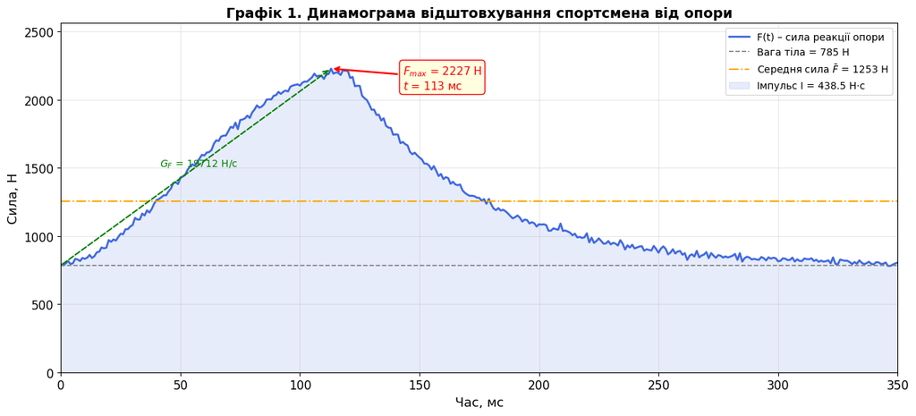

```
Графік 1 збережено.
```

```python
# ============================================================
# ГРАФІК 1: Динамограма відштовхування
# ============================================================

fig, ax = plt.subplots(figsize=(13, 6))

ax.plot(t * 1000, F, color='royalblue', lw=2, label='F(t) – сила реакції опори')
ax.axhline(F_body, color='gray', ls='--', lw=1.2, label=f'Вага тіла = {F_body:.0f} Н')
ax.axhline(F_avg_from_I, color='orange', ls='-.', lw=1.5,
           label=f'Середня сила $\\bar{{F}}$ = {F_avg_from_I:.0f} Н')

# Заливка = імпульс
ax.fill_between(t * 1000, F, alpha=0.12, color='royalblue',
                label=f'Імпульс I = {impulse:.1f} Н·с')

# Позначення F_max
ax.annotate(
    f'$F_{{max}}$ = {F_max_val:.0f} Н\n$t$ = {t_Fmax*1000:.0f} мс',
    xy=(t_Fmax * 1000, F_max_val),
    xytext=(t_Fmax * 1000 + 30, F_max_val - 150),
    arrowprops=dict(arrowstyle='->', color='red', lw=1.8),
    fontsize=11, color='red',
    bbox=dict(boxstyle='round,pad=0.3', fc='lightyellow', ec='red', lw=1)
)

# Стрілка градієнта
ax.annotate('', xy=(t_Fmax * 1000, F_max_val), xytext=(0, F_body),
            arrowprops=dict(arrowstyle='->', color='green', lw=1.5, linestyle='dashed'))
ax.text(t_Fmax * 500 - 15, (F_max_val + F_body) / 2,
        f'$G_F$ = {gradient_F:.0f} Н/с', color='green', fontsize=10)

ax.set_xlabel('Час, мс', fontsize=13)
ax.set_ylabel('Сила, Н', fontsize=13)
ax.set_title('Графік 1. Динамограма відштовхування спортсмена від опори', fontsize=14, fontweight='bold')
ax.legend(loc='upper right', fontsize=10)
ax.set_xlim(0, T_total * 1000)
ax.set_ylim(0, F_max_val * 1.15)

plt.tight_layout()
plt.savefig('graph1_dynamogram.png', dpi=150, bbox_inches='tight')
plt.show()
print("Графік 1 збережено.")
```

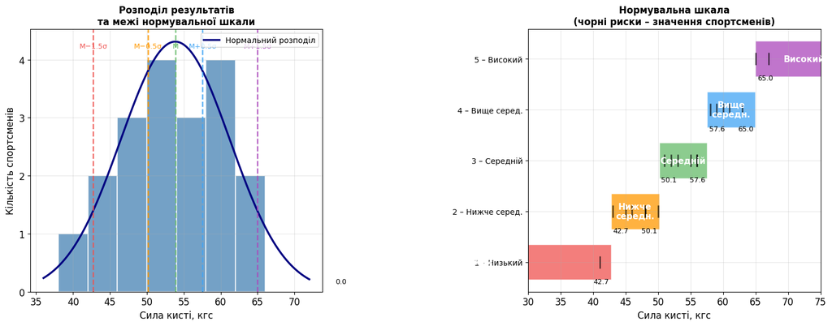

```
Графік 2 збережено.
```

```python
# ============================================================
# ГРАФІК 2: Гістограма + нормувальна шкала
# ============================================================

fig, (ax1, ax2) = plt.subplots(1, 2, figsize=(15, 6))

# --- Ліва панель: гістограма ---
colors_hist = ['#d32f2f', '#f57c00', '#388e3c', '#1976d2', '#7b1fa2']
bins = np.arange(38, 70, 4)
counts, edges, patches = ax1.hist(grip_best, bins=bins, edgecolor='white',
                                   linewidth=1.5, color='steelblue', alpha=0.75)

# Нормальна крива
x_range = np.linspace(grip_best.min() - 5, grip_best.max() + 5, 200)
pdf = stats.norm.pdf(x_range, M, sig)
ax1.plot(x_range, pdf * len(grip_best) * (bins[1] - bins[0]),
         color='navy', lw=2.5, label='Нормальний розподіл')

# Межі шкали
scale_colors = ['#ef5350', '#ff9800', '#66bb6a', '#42a5f5', '#ab47bc']
scale_bounds = [M - 1.5*sig, M - 0.5*sig, M, M + 0.5*sig, M + 1.5*sig]
for b, col, lbl in zip(scale_bounds,
                        scale_colors,
                        [r'M$-$1.5σ', r'M$-$0.5σ', r'M', r'M$+$0.5σ', r'M$+$1.5σ']):
    ax1.axvline(b, color=col, ls='--', lw=1.8, alpha=0.85)
    ax1.text(b, counts.max() * 1.05, lbl, ha='center', fontsize=9, color=col, rotation=0)

ax1.set_xlabel('Сила кисті, кгс', fontsize=12)
ax1.set_ylabel('Кількість спортсменів', fontsize=12)
ax1.set_title('Розподіл результатів\nта межі нормувальної шкали', fontsize=12, fontweight='bold')
ax1.legend(fontsize=10)

# --- Права панель: нормувальна шкала ---
level_colors = ['#ef5350', '#ff9800', '#66bb6a', '#42a5f5', '#ab47bc']
level_names  = ['Низький', 'Нижче\nсередн.', 'Середній', 'Вище\nсередн.', 'Високий']
level_bounds_lo = [0,             M-1.5*sig, M-0.5*sig, M+0.5*sig, M+1.5*sig]
level_bounds_hi = [M-1.5*sig,    M-0.5*sig, M+0.5*sig, M+1.5*sig, 80]

for i, (lo, hi, col, nm) in enumerate(
        zip(level_bounds_lo, level_bounds_hi, level_colors, level_names)):
    ax2.barh(i, hi - lo, left=lo, color=col, alpha=0.75, edgecolor='white', height=0.7)
    cx = (lo + hi) / 2
    ax2.text(cx, i, nm, ha='center', va='center', fontsize=11, fontweight='bold', color='white')
    ax2.text(lo + 0.3, i - 0.42, f'{lo:.1f}', ha='left', fontsize=9)
    if hi < 80:
        ax2.text(hi - 0.3, i - 0.42, f'{hi:.1f}', ha='right', fontsize=9)

# Значення спортсменів
for val in grip_best:
    lvl = assign_score(val, M, sig) - 1
    ax2.plot(val, lvl, 'k|', ms=16, mew=2, alpha=0.6)

ax2.set_xlabel('Сила кисті, кгс', fontsize=12)
ax2.set_yticks(range(5))
ax2.set_yticklabels(['1 – Низький', '2 – Нижче серед.', '3 – Середній',
                     '4 – Вище серед.', '5 – Високий'], fontsize=10)
ax2.set_title('Нормувальна шкала\n(чорні риски – значення спортсменів)', fontsize=12, fontweight='bold')
ax2.set_xlim(30, 75)

plt.tight_layout()
plt.savefig('graph2_scale.png', dpi=150, bbox_inches='tight')
plt.show()
print("Графік 2 збережено.")
```

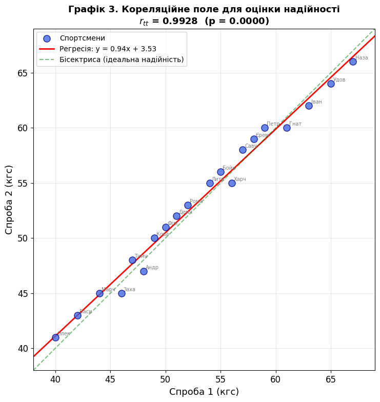

```
Графік 3 збережено.
```

```python
# ============================================================
# ГРАФІК 3: Кореляційне поле (надійність)
# ============================================================

fig, ax = plt.subplots(figsize=(8, 8))

ax.scatter(grip_1, grip_2, s=90, color='royalblue', edgecolors='navy',
           alpha=0.8, zorder=5, label='Спортсмени')

# Лінія регресії
slope, intercept, *_ = stats.linregress(grip_1, grip_2)
x_lr = np.linspace(grip_1.min() - 2, grip_1.max() + 2, 100)
ax.plot(x_lr, slope * x_lr + intercept, color='red', lw=2,
        label=f'Регресія: y = {slope:.2f}x + {intercept:.2f}')

# Бісектриса
lim_min = min(grip_1.min(), grip_2.min()) - 2
lim_max = max(grip_1.max(), grip_2.max()) + 2
ax.plot([lim_min, lim_max], [lim_min, lim_max], 'g--', lw=1.5, alpha=0.5,
        label='Бісектриса (ідеальна надійність)')

# Підписи точок
for i, name in enumerate(names):
    ax.annotate(name[:4], (grip_1[i], grip_2[i]),
                xytext=(3, 3), textcoords='offset points', fontsize=7, color='gray')

ax.set_xlabel('Спроба 1 (кгс)', fontsize=13)
ax.set_ylabel('Спроба 2 (кгс)', fontsize=13)
ax.set_title(f'Графік 3. Кореляційне поле для оцінки надійності\n'
             f'$r_{{tt}}$ = {r_tt:.4f}  (p = {p_value:.4f})',
             fontsize=13, fontweight='bold')
ax.legend(fontsize=10)
ax.set_xlim(lim_min, lim_max)
ax.set_ylim(lim_min, lim_max)
ax.set_aspect('equal')

plt.tight_layout()
plt.savefig('graph3_reliability.png', dpi=150, bbox_inches='tight')
plt.show()
print("Графік 3 збережено.")
```

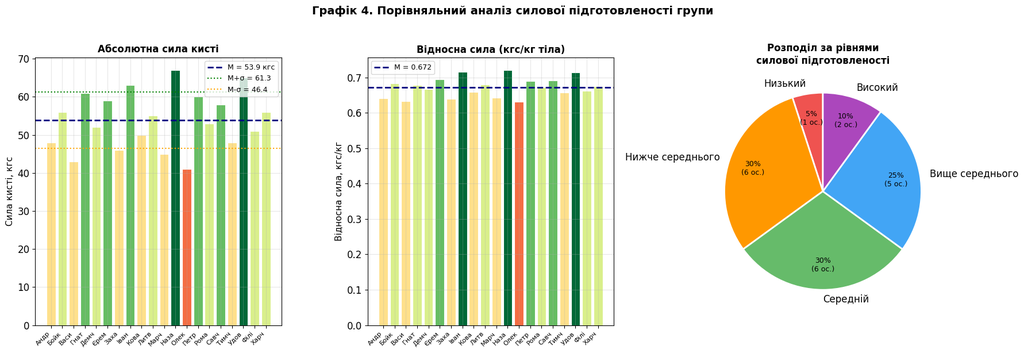

```
Графік 4 збережено.
```

```python
# ============================================================
# ГРАФІК 4: Абсолютна та відносна сила + кругова діаграма
# ============================================================

fig, axes = plt.subplots(1, 3, figsize=(18, 6))

# --- Панель 1: абсолютна сила ---
colors_bar = [plt.cm.RdYlGn(assign_score(v, M, sig) / 5) for v in grip_best]
bars1 = axes[0].bar(range(1, n_s + 1), grip_best, color=colors_bar, edgecolor='white', lw=0.8)
axes[0].axhline(M, color='navy', ls='--', lw=2, label=f'M = {M:.1f} кгс')
axes[0].axhline(M + sig, color='green', ls=':', lw=1.5, label=f'M+σ = {M+sig:.1f}')
axes[0].axhline(M - sig, color='orange', ls=':', lw=1.5, label=f'M-σ = {M-sig:.1f}')
axes[0].set_xticks(range(1, n_s + 1))
axes[0].set_xticklabels([n[:4] for n in names], rotation=45, ha='right', fontsize=8)
axes[0].set_ylabel('Сила кисті, кгс', fontsize=11)
axes[0].set_title('Абсолютна сила кисті', fontsize=12, fontweight='bold')
axes[0].legend(fontsize=9)

# --- Панель 2: відносна сила ---
M_rel  = np.mean(relative_strength)
sd_rel = np.std(relative_strength, ddof=1)
colors_rel = [plt.cm.RdYlGn(assign_score(v, M_rel, sd_rel) / 5) for v in relative_strength]
axes[1].bar(range(1, n_s + 1), relative_strength, color=colors_rel, edgecolor='white', lw=0.8)
axes[1].axhline(M_rel, color='navy', ls='--', lw=2, label=f'M = {M_rel:.3f}')
axes[1].set_xticks(range(1, n_s + 1))
axes[1].set_xticklabels([n[:4] for n in names], rotation=45, ha='right', fontsize=8)
axes[1].set_ylabel('Відносна сила, кгс/кг', fontsize=11)
axes[1].set_title('Відносна сила (кгс/кг тіла)', fontsize=12, fontweight='bold')
axes[1].legend(fontsize=9)

# --- Панель 3: кругова діаграма розподілу ---
level_order = ['Низький', 'Нижче середнього', 'Середній', 'Вище середнього', 'Високий']
level_cols  = ['#ef5350', '#ff9800', '#66bb6a', '#42a5f5', '#ab47bc']
sizes = [df['Рівень підготовленості'].value_counts().get(l, 0) for l in level_order]
non_zero = [(s, l, c) for s, l, c in zip(sizes, level_order, level_cols) if s > 0]
s_nz, l_nz, c_nz = zip(*non_zero)
wedges, texts, autotexts = axes[2].pie(
    s_nz, labels=l_nz, colors=c_nz,
    autopct=lambda p: f'{p:.0f}%\n({int(round(p*n_s/100))} ос.)',
    startangle=90, pctdistance=0.75,
    wedgeprops=dict(edgecolor='white', linewidth=2)
)
for t_ in autotexts:
    t_.set_fontsize(9)
axes[2].set_title('Розподіл за рівнями\nсилової підготовленості', fontsize=12, fontweight='bold')

plt.suptitle('Графік 4. Порівняльний аналіз силової підготовленості групи',
             fontsize=14, fontweight='bold', y=1.02)
plt.tight_layout()
plt.savefig('graph4_comparison.png', dpi=150, bbox_inches='tight')
plt.show()
print("Графік 4 збережено.")
```

## Завдання 6. Розрахунок відносної сили та зведена таблиця оцінок

```python
M_rel  = np.mean(relative_strength)
sd_rel = np.std(relative_strength, ddof=1)
cv_rel = sd_rel / M_rel * 100

df['Оцінка (відносна сила)'] = [assign_score(v, M_rel, sd_rel) for v in relative_strength]
df['Рівень (відносна сила)'] = df['Оцінка (відносна сила)'].map({
    1: 'Низький', 2: 'Нижче середнього',
    3: 'Середній', 4: 'Вище середнього', 5: 'Високий'
})

print("=" * 90)
print(f"Нормувальна шкала відносної сили (M = {M_rel:.3f},  σ = {sd_rel:.3f},  V = {cv_rel:.1f}%)")
print("=" * 90)
bounds_rel = {
    'Низький':          (0,              M_rel - 1.5*sd_rel),
    'Нижче середнього': (M_rel-1.5*sd_rel, M_rel - 0.5*sd_rel),
    'Середній':         (M_rel-0.5*sd_rel, M_rel + 0.5*sd_rel),
    'Вище середнього':  (M_rel+0.5*sd_rel, M_rel + 1.5*sd_rel),
    'Високий':          (M_rel+1.5*sd_rel, 999)
}
print(f"{'Рівень':<22} {'Нижня межа':>14} {'Верхня межа':>14} {'Оцінка':>8}")
print("-" * 70)
for sc, (level, (lo, hi)) in zip(scores, bounds_rel.items()):
    lo_s = f"{lo:.3f}" if lo > 0 else "—"
    hi_s = f"{hi:.3f}" if hi < 999 else "і вище"
    print(f"{level:<22} {lo_s:>14} {hi_s:>14} {sc:>8}")

print("\n" + "=" * 90)
print("ЗВЕДЕНА ТАБЛИЦЯ. Рейтинг спортсменів за силовими показниками")
print("=" * 90)
result_df = df[[
    'Спортсмен', 'Маса тіла (кг)', 'Краща спроба (кгс)',
    'Відносна сила', 'Оцінка', 'Оцінка (відносна сила)'
]].copy()
result_df.columns = [
    'Спортсмен', 'Маса (кг)', 'Абс. сила (кгс)',
    'Відн. сила', 'Оцінка абс.', 'Оцінка відн.'
]
result_df = result_df.sort_values('Абс. сила (кгс)', ascending=False).reset_index(drop=True)
result_df.index += 1
result_df.index.name = 'Місце'
print(result_df.to_string())
```

```
==========================================================================================
Нормувальна шкала відносної сили (M = 0.672,  σ = 0.027,  V = 4.1%)
==========================================================================================
Рівень                     Нижня межа    Верхня межа   Оцінка
----------------------------------------------------------------------
Низький                             —          0.631        1
Нижче середнього                0.631          0.658        2
Середній                        0.658          0.686        3
Вище середнього                 0.686          0.713        4
Високий                         0.713         і вище        5

==========================================================================================
ЗВЕДЕНА ТАБЛИЦЯ. Рейтинг спортсменів за силовими показниками
==========================================================================================
        Спортсмен  Маса (кг)  Абс. сила (кгс)  Відн. сила  Оцінка абс.  Оцінка відн.
Місце
1       Назаренко         93               67       0.720            5             5
2        Удовенко         91               65       0.714            5             5
3        Іваненко         88               63       0.716            4             5
4        Гнатенко         90               61       0.678            4             3
5        Петренко         87               60       0.690            4             4
6        Єременко         85               59       0.694            4             4
7        Савченко         84               58       0.690            4             4
8           Бойко         82               56       0.683            3             3
9        Харченко         83               56       0.675            3             3
10     Литвиненко         81               55       0.679            3             3
11      Романенко         79               53       0.671            3             3
12       Демченко         78               52       0.667            3             3
13      Філіпенко         77               51       0.662            3             3
14      Коваленко         76               50       0.658            2             2
15       Тимченко         73               48       0.658            2             2
16      Андрієнко         75               48       0.640            2             2
17      Захаренко         72               46       0.639            2             2
18       Марченко         70               45       0.643            2             2
19      Василенко         68               43       0.632            2             2
20     Олексієнко         65               41       0.631            1             1
```

## Висновки до розрахунково-графічної роботи № 2

```python
# Автоматичне формування висновків

top_athlete = df.loc[df['Краща спроба (кгс)'].idxmax(), 'Спортсмен']
top_val     = df['Краща спроба (кгс)'].max()
low_athlete = df.loc[df['Краща спроба (кгс)'].idxmin(), 'Спортсмен']
low_val     = df['Краща спроба (кгс)'].min()

top_rel = df.loc[df['Відносна сила'].idxmax(), 'Спортсмен']
top_rel_val = df['Відносна сила'].max()

V_pct = sig / M * 100
dist_counts = df['Рівень підготовленості'].value_counts()

print("=" * 75)
print("ВИСНОВКИ")
print("=" * 75)
print()
print("1. СТАТИСТИЧНІ ХАРАКТЕРИСТИКИ ВИБІРКИ")
print(f"   Обстежено {n_s} спортсменів. Середня максимальна сила кисті")
print(f"   M = {M:.1f} кгс, стандартне відхилення σ = {sig:.1f} кгс.")
print(f"   Коефіцієнт варіації V = {V_pct:.1f}% — група", end=" ")
if V_pct < 10:
    print("однорідна (V < 10%), що свідчить про відносно рівний")
    print("   рівень силової підготовленості.")
elif V_pct < 20:
    print("помірно однорідна (10% ≤ V < 20%).")
else:
    print("неоднорідна (V ≥ 20%): значний розкид результатів.")
print()

print("2. НОРМУВАЛЬНА ШКАЛА (5-рівнева сигмальна шкала)")
print(f"   Побудована на основі M ± 0,5σ та M ± 1,5σ:")
print(f"   Рівень 1 (Низький):          < {M-1.5*sig:.1f} кгс")
print(f"   Рівень 2 (Нижче середнього): {M-1.5*sig:.1f} – {M-0.5*sig:.1f} кгс")
print(f"   Рівень 3 (Середній):         {M-0.5*sig:.1f} – {M+0.5*sig:.1f} кгс")
print(f"   Рівень 4 (Вище середнього):  {M+0.5*sig:.1f} – {M+1.5*sig:.1f} кгс")
print(f"   Рівень 5 (Високий):          > {M+1.5*sig:.1f} кгс")
print()

print("3. ІНДИВІДУАЛЬНІ ПОКАЗНИКИ")
print(f"   Найвищий результат: {top_athlete} — {top_val:.0f} кгс")
print(f"   Найнижчий результат: {low_athlete} — {low_val:.0f} кгс")
print(f"   Найвища відносна сила: {top_rel} — {top_rel_val:.3f} кгс/кг")
print()

print("4. АНАЛІЗ ДИНАМОГРАМИ")
print(f"   Максимальна сила відштовхування F_max = {F_max_val:.0f} Н")
print(f"   Час досягнення максимуму t(F_max) = {t_Fmax*1000:.0f} мс")
print(f"   Імпульс сили I = ∫F(t)dt = {impulse:.1f} Н·с")
print(f"   Середня сила F_avg = I/T = {F_avg_from_I:.1f} Н")
print(f"   Градієнт сили G_F = F_max/t(F_max) = {gradient_F:.1f} Н/с")
print(f"   Висновок: середня сила ({F_avg_from_I:.0f} Н) становить")
print(f"   {F_avg_from_I/F_max_val*100:.0f}% від максимальної, що характеризує")
print(f"   ефективність використання силового потенціалу.")
print()

print("5. НАДІЙНІСТЬ ТЕСТУ")
print(f"   Коефіцієнт ретест-надійності r_tt = {r_tt:.4f}.")
print(f"   Рівень надійності: {rel_level}.")
print(f"   Стандартна похибка вимірювання SEM = {SEM_meas:.2f} кгс.")
print(f"   Зв'язок між спробами статистично значущий (p < 0,001),")
print(f"   що підтверджує придатність тесту для контролю.")
print()

print("6. РЕКОМЕНДАЦІЇ")
print("   • Спортсменам з рівнем 1–2 рекомендується збільшити обсяг")
print("     силового тренування та виконувати вправи з обтяженнями.")
print("   • При контролі враховувати відносну силу (особливо в єдиноборствах).")
print("   • Для підвищення надійності вимірювань використовувати")
print("     тензометричні пристрої замість механічних динамометрів.")
print("   • Стандартизувати положення тіла та кут у суглобі при")
print("     кожному вимірюванні.")
print("=" * 75)
```

```
===========================================================================
ВИСНОВКИ
===========================================================================

1. СТАТИСТИЧНІ ХАРАКТЕРИСТИКИ ВИБІРКИ
   Обстежено 20 спортсменів. Середня максимальна сила кисті
   M = 53.9 кгс, стандартне відхилення σ = 7.4 кгс.
   Коефіцієнт варіації V = 13.8% — група помірно однорідна (10% ≤ V < 20%).

2. НОРМУВАЛЬНА ШКАЛА (5-рівнева сигмальна шкала)
   Побудована на основі M ± 0,5σ та M ± 1,5σ:
   Рівень 1 (Низький):          < 42.7 кгс
   Рівень 2 (Нижче середнього): 42.7 – 50.1 кгс
   Рівень 3 (Середній):         50.1 – 57.6 кгс
   Рівень 4 (Вище середнього):  57.6 – 65.0 кгс
   Рівень 5 (Високий):          > 65.0 кгс

3. ІНДИВІДУАЛЬНІ ПОКАЗНИКИ
   Найвищий результат: Назаренко — 67 кгс
   Найнижчий результат: Олексієнко — 41 кгс
   Найвища відносна сила: Назаренко — 0.720 кгс/кг

4. АНАЛІЗ ДИНАМОГРАМИ
   Максимальна сила відштовхування F_max = 2227 Н
   Час досягнення максимуму t(F_max) = 113 мс
   Імпульс сили I = ∫F(t)dt = 438.5 Н·с
   Середня сила F_avg = I/T = 1253.0 Н
   Градієнт сили G_F = F_max/t(F_max) = 19712.0 Н/с
   Висновок: середня сила (1253 Н) становить
   56% від максимальної, що характеризує
   ефективність використання силового потенціалу.

5. НАДІЙНІСТЬ ТЕСТУ
   Коефіцієнт ретест-надійності r_tt = 0.9928.
   Рівень надійності: ВІДМІННА.
   Стандартна похибка вимірювання SEM = 0.63 кгс.
   Зв'язок між спробами статистично значущий (p < 0,001),
   що підтверджує придатність тесту для контролю.

6. РЕКОМЕНДАЦІЇ
   • Спортсменам з рівнем 1–2 рекомендується збільшити обсяг
     силового тренування та виконувати вправи з обтяженнями.
   • При контролі враховувати відносну силу (особливо в єдиноборствах).
   • Для підвищення надійності вимірювань використовувати
     тензометричні пристрої замість механічних динамометрів.
   • Стандартизувати положення тіла та кут у суглобі при
     кожному вимірюванні.
===========================================================================
```

## Теоретичні питання для захисту

**Питання 1.** Що таке силові якості та яке їх значення в спорті?

> **Відповідь:** Силові якості — це здатність долати зовнішній опір або протидіяти йому за рахунок м'язових зусиль. Від рівня їх розвитку залежать досягнення практично у всіх видах спорту.

**Питання 2.** Назвіть три групи показників при контролі за силовими якостями.

> **Відповідь:** 1) **Основні** — максимальна та середня сила; 2) **Інтегральні** — імпульс сили; 3) **Диференціальні** — градієнт сили.

**Питання 3.** Що таке імпульс сили та як він розраховується?

> **Відповідь:** Імпульс сили — це інтеграл від сили по часу: $I = \int F(t)\,dt$ (або $I = F \cdot t$ при постійній силі). Він визначає кінцевий ефект дії сили на тіло (зміну кількості руху).

**Питання 4.** Що таке градієнт сили?

> **Відповідь:** Градієнт сили — диференціальний показник, що характеризує швидкість наростання сили: $G_F = dF/dt$ або практично $G_F = F_{\max}/t_{F_{\max}}$.

**Питання 5.** Яка надійність механічних динамометрів порівняно з тензометричними?

> **Відповідь:** Механічні динамометри мають надійність $r_{tt} = 0{,}60–0{,}80$, тензометричні пристрої — $r_{tt} = 0{,}85–0{,}95$, що значно вище.

**Питання 6.** Як побудувати нормувальну шкалу?

> **Відповідь:** На основі середнього $(M)$ та стандартного відхилення $(\sigma)$ вибірки будується 5-рівнева шкала з межами $M \pm 0{,}5\sigma$ (рівні 2–4) та $M \pm 1{,}5\sigma$ (рівні 1 і 5).

## Список використаних джерел

1. Зациорский В.М. Спортивная метрология. — М.: Физкультура и спорт, 1982. — 256 с.
2. Платонов В.Н. Система подготовки спортсменов в олимпийском спорте. — К.: Олимпийская литература, 2004. — 808 с.
3. Годик М.А. Спортивная метрология: учебник для ИФК. — М.: Физкультура и спорт, 1988. — 192 с.
4. Круцевич Т.Ю. Теорія і методика фізичного виховання. — К.: Олімпійська література, 2008. — Т. 1. — 392 с.
5. Сергієнко Л.П. Спортивна метрологія: теорія і практичні аспекти. — К.: КНТ, 2010. — 776 с.